# R Notebook

```r
library(tidyverse)
```

```r
library(dplyr)
```

# Project 1

Loading the file

```r
female <- read.csv("female.csv")
```

```r
# Determine whether the female dataset is a data frame
is.data.frame(female)
```

```
[1] TRUE
```

```r
# printing the first few rows of the data frame
head(female)
```

|  | Series.Name | Series.Code | Country.Name | Country.Code | X1990..YR1990. | X2000..YR2000. | X2012..YR2012. | X2013..YR2013. | X2014..YR2014. | X2015..YR2015. | X2016..YR2016. | X2017..YR2017. | X2018..YR2018. | X2019..YR2019. | X2020..YR2020. | X2021..YR2021. |
| --- | --- | --- | --- | --- | --- | --- | --- | --- | --- | --- | --- | --- | --- | --- | --- | --- |
| 1 | Account ownership at a financial institution or with a mobile-money-service provider, female (% of population ages 15+) | FX.OWN.TOTL.FE.ZS | Afghanistan | AFG | .. | .. | .. | .. | 3.81 | .. | .. | 7.16 | .. | .. | .. | 4.7 |
| 2 | Account ownership at a financial institution or with a mobile-money-service provider, female (% of population ages 15+) | FX.OWN.TOTL.FE.ZS | Albania | ALB | .. | .. | .. | .. | 33.59 | .. | .. | 38.1 | .. | .. | .. | 45.69 |
| 3 | Account ownership at a financial institution or with a mobile-money-service provider, female (% of population ages 15+) | FX.OWN.TOTL.FE.ZS | Algeria | DZA | .. | .. | .. | .. | 40.07 | .. | .. | 29.27 | .. | .. | .. | 31.19 |
| 4 | Account ownership at a financial institution or with a mobile-money-service provider, female (% of population ages 15+) | FX.OWN.TOTL.FE.ZS | American Samoa | ASM | .. | .. | .. | .. | .. | .. | .. | .. | .. | .. | .. | .. |
| 5 | Account ownership at a financial institution or with a mobile-money-service provider, female (% of population ages 15+) | FX.OWN.TOTL.FE.ZS | Andorra | AND | .. | .. | .. | .. | .. | .. | .. | .. | .. | .. | .. | .. |
| 6 | Account ownership at a financial institution or with a mobile-money-service provider, female (% of population ages 15+) | FX.OWN.TOTL.FE.ZS | Angola | AGO | .. | .. | .. | .. | 22.33 | .. | .. | .. | .. | .. | .. | .. |

```r
# selecting rows we want to use in our analysis
female <- female %>%
filter(Country.Name == "Brazil" | Country.Name == "India" | Country.Name == "United States")
```

```r
# we remove the null and unnecessary columns and then rename the columns
female <- female[ -c(1,2,4,5:8,10:11,13:15)] %>%
  rename("2014" = 2, "2017" = 3, "2021" = 4)

head(female)
```

|  | Country.Name | 2014 | 2017 | 2021 |
| --- | --- | --- | --- | --- |
| 1 | Brazil | 64.77 | 67.51 | 80.87 |
| 2 | India | 43.13 | 76.64 | 77.55 |
| 3 | United States | 94.8 | 92.69 | 96.79 |

```r
# we flip the rows and columns of the dataframe (transpose) and remove the first column
transpose_f <- data.frame(t(female[-1]))
# Assign new columns from  the first column of the original df
colnames(transpose_f) <- female[, 1]

head(transpose_f)
```

|  | Brazil | India | United States |
| --- | --- | --- | --- |
| 2014 | 64.77 | 43.13 | 94.8 |
| 2017 | 67.51 | 76.64 | 92.69 |
| 2021 | 80.87 | 77.55 | 96.79 |

```r
#
# return a class of each column using the supply function that takes a list, vector, and return a vector of the results.
print(sapply(transpose_f, class))
```

```
       Brazil         India United States
  "character"   "character"   "character"
```

```r
# turn the entries to numeric

transpose_f$Brazil = as.numeric(as.character(transpose_f$Brazil))
transpose_f$India = as.numeric(as.character(transpose_f$India))
transpose_f$"United States" = as.numeric(as.character((transpose_f$"United States")))

head(transpose_f)
```

|  | Brazil | India | United States |
| --- | --- | --- | --- |
| 2014 | 64.77 | 43.13 | 94.80 |
| 2017 | 67.51 | 76.64 | 92.69 |
| 2021 | 80.87 | 77.55 | 96.79 |

```r
# summarize each column with mean
summarise_each(transpose_f, list(mean))
```

| Brazil | India | United States |
| --- | --- | --- |
| 71.05 | 65.77333 | 94.76 |

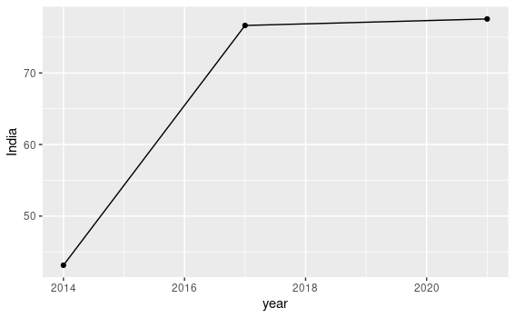

```r
# Plot the change in ownership percentage overtime for the data from India
year <- c(2014, 2017, 2021)

ggplot(data=transpose_f, aes(x=year, y=India, group=1)) +
  geom_line() +
  geom_point()
```

Merging two datasets together .

```r
male <- read.csv(file = "male.csv")
male <- male %>%
  filter(Country.Name == "Brazil" | Country.Name == "India" | Country.Name == "United States")

male <- male[ -c(1,2,4,5:8,10:11,13:15)] %>%
  rename("2014" = 2, "2017" = 3, "2021" = 4)

transpose_m <- data.frame(t(male[-1]))
colnames(transpose_m) <- male[, 1]

transpose_m$Brazil = as.numeric(as.character(transpose_m$Brazil))
transpose_m$India = as.numeric(as.character(transpose_m$India))
transpose_m$"United States" = as.numeric(as.character((transpose_m$"United States")))


head(transpose_m)
```

|  | Brazil | India | United States |
| --- | --- | --- | --- |
| 2014 | 71.69 | 62.76 | 92.36 |
| 2017 | 72.85 | 83.01 | 93.57 |
| 2021 | 87.05 | 77.51 | 93.09 |

```r
transpose_m <- rename(transpose_m, "Brazil_m" = 1, "India_m" = 2, "United_States_m" = 3)


head(transpose_m)
```

|  | Brazil_m | India_m | United_States_m |
| --- | --- | --- | --- |
| 2014 | 71.69 | 62.76 | 92.36 |
| 2017 | 72.85 | 83.01 | 93.57 |
| 2021 | 87.05 | 77.51 | 93.09 |

```r
# we add ne columns to the dataframes
transpose_m <- rownames_to_column(transpose_m, var="Year")
transpose_f <- rownames_to_column(transpose_f, var="Year")
```

```r
# Merge the two dataframes based on the year column
acct_owner_by_gender <- merge(x = transpose_m, y = transpose_f, by = "Year", all.x = TRUE)

acct_owner_by_gender <- rename(acct_owner_by_gender, "United_States" = 7)

head(acct_owner_by_gender)
```

|  | Year | Brazil_m | India_m | United_States_m | Brazil | India | United_States |
| --- | --- | --- | --- | --- | --- | --- | --- |
| 1 | 2014 | 71.69 | 62.76 | 92.36 | 64.77 | 43.13 | 94.80 |
| 2 | 2017 | 72.85 | 83.01 | 93.57 | 67.51 | 76.64 | 92.69 |
| 3 | 2021 | 87.05 | 77.51 | 93.09 | 80.87 | 77.55 | 96.79 |

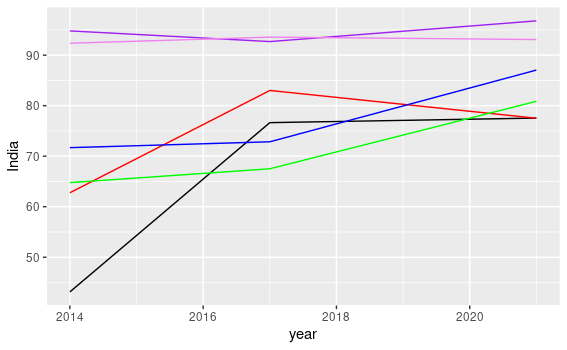

```r
# Visualize the two dataframes

gfg_plot <- ggplot(acct_owner_by_gender, aes(x=year)) +
geom_line(aes(y = India), color = "black") +
geom_line(aes(y = India_m), color = "red") +
geom_line(aes(y = Brazil), color = "green") +
geom_line(aes(y = Brazil_m), color = "blue") +
geom_line(aes(y = United_States), color = "purple") +
geom_line(aes(y = United_States_m), color = "violet")

gfg_plot
```

**Project 1** i) (Cleaning up the final plot) The final plot is somewhat misleading: the y-axis is titled “India”. Write down the code that will change it to percentage ownership

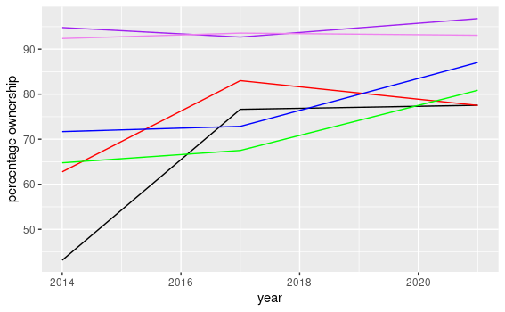

```r
gfg_plot <- ggplot(acct_owner_by_gender, aes(x=year)) +
geom_line(aes(y = India), color = "black") +
geom_line(aes(y = India_m), color = "red") +
geom_line(aes(y = Brazil), color = "green") +
geom_line(aes(y = Brazil_m), color = "blue") +
geom_line(aes(y = United_States), color = "purple") +
geom_line(aes(y = United_States_m), color = "violet") +
ylab("percentage ownership")
gfg_plot
```

ii). (Drawing Conclusions) After drawing the plot that includes how percentages change over time, use this to draw some conclusions on the how the ownership percentages have been changed. For example, you can discuss whether males have more account ownership than females and whether the data suggests that account ownership percentages are on the rise Conclusions.

-The percentage ownership for males in India was higher than the percentage ownership for females for the year 2014 to 2020 but percentage was the same in the year 2021. -The percentage ownership for males in Brazil was higher than the percentage ownership for females throughout the years 2014 - 2020 -The percentage ownership for males was constant throught the years in United States while the percentage ownership for females was high from 2014 to 2016 declined from 2016 to 2018 then was higher as from 2018. -Generally the average percentage ownership for both males and females in United states was higher than those in India and Brazil.

3. (Cherry Picking) Is it possible to say that account percentages have been increasing if you disregard a certain year? Does this change if you focus on a particular country and gender combinations?

-Generally the account percentages has been increasing over the years.

(Summarizing the data yourself) Do a similar analysis using the csv files:

1. Primary data

```r
primary <- read.csv("primary.csv")
head(primary)
```

|  | Series.Name | Series.Code | Country.Name | Country.Code | X1990..YR1990. | X2000..YR2000. | X2012..YR2012. | X2013..YR2013. | X2014..YR2014. | X2015..YR2015. | X2016..YR2016. | X2017..YR2017. | X2018..YR2018. | X2019..YR2019. | X2020..YR2020. | X2021..YR2021. |
| --- | --- | --- | --- | --- | --- | --- | --- | --- | --- | --- | --- | --- | --- | --- | --- | --- |
| 1 | Account ownership at a financial institution or with a mobile-money-service provider, primary education or less (% of population ages 15+) | FX.OWN.TOTL.PL.ZS | Afghanistan | AFG | .. | .. | .. | .. | 4.83 | .. | .. | 8.89 | .. | .. | .. | 5.18 |
| 2 | Account ownership at a financial institution or with a mobile-money-service provider, primary education or less (% of population ages 15+) | FX.OWN.TOTL.PL.ZS | Albania | ALB | .. | .. | .. | .. | 24.01 | .. | .. | 27.5 | .. | .. | .. | 34.36 |
| 3 | Account ownership at a financial institution or with a mobile-money-service provider, primary education or less (% of population ages 15+) | FX.OWN.TOTL.PL.ZS | Algeria | DZA | .. | .. | .. | .. | 48.35 | .. | .. | 38.95 | .. | .. | .. | 38.99 |
| 4 | Account ownership at a financial institution or with a mobile-money-service provider, primary education or less (% of population ages 15+) | FX.OWN.TOTL.PL.ZS | American Samoa | ASM | .. | .. | .. | .. | .. | .. | .. | .. | .. | .. | .. | .. |
| 5 | Account ownership at a financial institution or with a mobile-money-service provider, primary education or less (% of population ages 15+) | FX.OWN.TOTL.PL.ZS | Andorra | AND | .. | .. | .. | .. | .. | .. | .. | .. | .. | .. | .. | .. |
| 6 | Account ownership at a financial institution or with a mobile-money-service provider, primary education or less (% of population ages 15+) | FX.OWN.TOTL.PL.ZS | Angola | AGO | .. | .. | .. | .. | 14.35 | .. | .. | .. | .. | .. | .. | .. |

```r
is.data.frame(primary)
```

```
[1] TRUE
```

```r
primary <- primary %>%
  filter(Country.Name == "China" | Country.Name == "Israel" | Country.Name == "Nigeria" | Country.Name == "France" | Country.Name == "Algeria")
```

```r
head(primary)
```

|  | Series.Name | Series.Code | Country.Name | Country.Code | X1990..YR1990. | X2000..YR2000. | X2012..YR2012. | X2013..YR2013. | X2014..YR2014. | X2015..YR2015. | X2016..YR2016. | X2017..YR2017. | X2018..YR2018. | X2019..YR2019. | X2020..YR2020. | X2021..YR2021. |
| --- | --- | --- | --- | --- | --- | --- | --- | --- | --- | --- | --- | --- | --- | --- | --- | --- |
| 1 | Account ownership at a financial institution or with a mobile-money-service provider, primary education or less (% of population ages 15+) | FX.OWN.TOTL.PL.ZS | Algeria | DZA | .. | .. | .. | .. | 48.35 | .. | .. | 38.95 | .. | .. | .. | 38.99 |
| 2 | Account ownership at a financial institution or with a mobile-money-service provider, primary education or less (% of population ages 15+) | FX.OWN.TOTL.PL.ZS | China | CHN | .. | .. | .. | .. | 72.82 | .. | .. | 71.39 | .. | .. | .. | 83.02 |
| 3 | Account ownership at a financial institution or with a mobile-money-service provider, primary education or less (% of population ages 15+) | FX.OWN.TOTL.PL.ZS | France | FRA | .. | .. | .. | .. | 83.36 | .. | .. | 79.82 | .. | .. | .. | 95.87 |
| 4 | Account ownership at a financial institution or with a mobile-money-service provider, primary education or less (% of population ages 15+) | FX.OWN.TOTL.PL.ZS | Israel | ISR | .. | .. | .. | .. | 83.69 | .. | .. | 88.29 | .. | .. | .. | 62.76 |
| 5 | Account ownership at a financial institution or with a mobile-money-service provider, primary education or less (% of population ages 15+) | FX.OWN.TOTL.PL.ZS | Nigeria | NGA | .. | .. | .. | .. | 28.08 | .. | .. | 16.05 | .. | .. | .. | 25.8 |

```r
# Drop unnecessary columns
primary <- primary[ -c(1,2,4,5:8,10:11,13:15)] %>%
  rename("2014" = 2, "2017" = 3, "2021" = 4)

head(primary)
```

|  | Country.Name | 2014 | 2017 | 2021 |
| --- | --- | --- | --- | --- |
| 1 | Algeria | 48.35 | 38.95 | 38.99 |
| 2 | China | 72.82 | 71.39 | 83.02 |
| 3 | France | 83.36 | 79.82 | 95.87 |
| 4 | Israel | 83.69 | 88.29 | 62.76 |
| 5 | Nigeria | 28.08 | 16.05 | 25.8 |

```r
transpose_p <- data.frame(t(primary[-1]))
colnames(transpose_p) <- primary[, 1]

head(transpose_p)
```

|  | Algeria | China | France | Israel | Nigeria |
| --- | --- | --- | --- | --- | --- |
| 2014 | 48.35 | 72.82 | 83.36 | 83.69 | 28.08 |
| 2017 | 38.95 | 71.39 | 79.82 | 88.29 | 16.05 |
| 2021 | 38.99 | 83.02 | 95.87 | 62.76 | 25.8 |

```r
print(sapply(transpose_p, class))
```

```
    Algeria       China      France      Israel     Nigeria
"character" "character" "character" "character" "character"
```

```r
# converting the character values to numeric
transpose_p$Algeria = as.numeric(as.character(transpose_p$Algeria))
transpose_p$China = as.numeric(as.character(transpose_p$China))
transpose_p$Nigeria = as.numeric(as.character(transpose_p$Nigeria))
transpose_p$France = as.numeric(as.character(transpose_p$France))
transpose_p$Israel = as.numeric(as.character(transpose_p$Israel))


head(transpose_p)
```

|  | Algeria | China | France | Israel | Nigeria |
| --- | --- | --- | --- | --- | --- |
| 2014 | 48.35 | 72.82 | 83.36 | 83.69 | 28.08 |
| 2017 | 38.95 | 71.39 | 79.82 | 88.29 | 16.05 |
| 2021 | 38.99 | 83.02 | 95.87 | 62.76 | 25.80 |

```r
#Summary of each category
summarise_each(transpose_p, list(mean))
```

| Algeria | China | France | Israel | Nigeria |
| --- | --- | --- | --- | --- |
| 42.09667 | 75.74333 | 86.35 | 78.24667 | 23.31 |

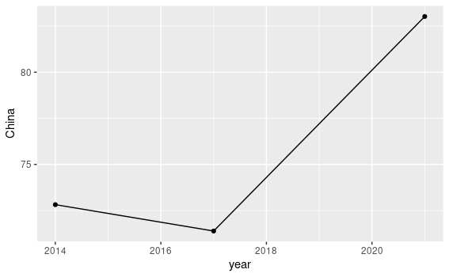

```r
year <- c(2014, 2017, 2021)

ggplot(data = transpose_p, aes(x=year, y=China, group = 1)) +
  geom_line() +
  geom_point()
```

Merging the two datasets together

```r
secondary <- read.csv(file = "secondary.csv")

secondary <- secondary %>%
  filter(Country.Name == "China" | Country.Name == "Israel" | Country.Name == "Nigeria" | Country.Name == "France" | Country.Name == "Algeria")

secondary <- secondary[ -c(1,2,4,5:8,10:11,13:15)] %>%
rename("2014" = 2, "2017" = 3, "2021" = 4)


transpose_s <- data.frame(t(secondary[-1]))
colnames(transpose_s) <- secondary[, 1]

# converting the character values to numeric
transpose_s$Algeria = as.numeric(as.character(transpose_s$Algeria))
transpose_s$China = as.numeric(as.character(transpose_s$China))
transpose_s$Nigeria = as.numeric(as.character(transpose_s$Nigeria))
transpose_s$France = as.numeric(as.character(transpose_s$France))
transpose_s$Israel = as.numeric(as.character(transpose_s$Israel))
```

```r
head(transpose_s)
```

|  | Algeria | China | France | Israel | Nigeria |
| --- | --- | --- | --- | --- | --- |
| 2014 | 55.32 | 89.84 | 97.26 | 90.17 | 56.03 |
| 2017 | 48.96 | 94.14 | 97.23 | 93.01 | 59.30 |
| 2021 | 46.23 | 97.21 | 99.76 | 94.27 | 65.20 |

```r
transpose_s <- rename(transpose_s, "Algeria_s" = 1, "China_s" = 2, "France_s" = 3, "Israel_s" = 4, "Nigeria_s" = 5)

head(transpose_s)
```

|  | Algeria_s | China_s | France_s | Israel_s | Nigeria_s |
| --- | --- | --- | --- | --- | --- |
| 2014 | 55.32 | 89.84 | 97.26 | 90.17 | 56.03 |
| 2017 | 48.96 | 94.14 | 97.23 | 93.01 | 59.30 |
| 2021 | 46.23 | 97.21 | 99.76 | 94.27 | 65.20 |

```r
transpose_p <- rownames_to_column(transpose_p, var="Year")
transpose_s <- rownames_to_column(transpose_s, var="Year")
```

```r
acct_owner_by_lev_educ <- merge(x = transpose_s, y=transpose_p, by ="Year", all.x = TRUE)

head(acct_owner_by_lev_educ)
```

|  | Year | Algeria_s | China_s | France_s | Israel_s | Nigeria_s | Algeria | China | France | Israel | Nigeria |
| --- | --- | --- | --- | --- | --- | --- | --- | --- | --- | --- | --- |
| 1 | 2014 | 55.32 | 89.84 | 97.26 | 90.17 | 56.03 | 48.35 | 72.82 | 83.36 | 83.69 | 28.08 |
| 2 | 2017 | 48.96 | 94.14 | 97.23 | 93.01 | 59.30 | 38.95 | 71.39 | 79.82 | 88.29 | 16.05 |
| 3 | 2021 | 46.23 | 97.21 | 99.76 | 94.27 | 65.20 | 38.99 | 83.02 | 95.87 | 62.76 | 25.80 |

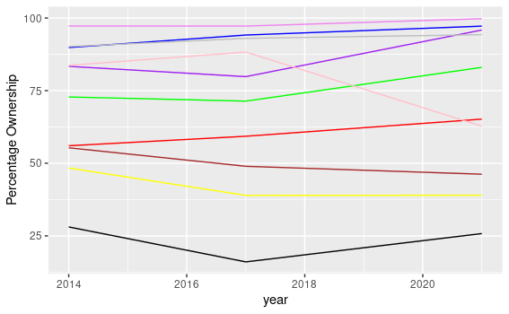

```r
gfg_plot <- ggplot(acct_owner_by_lev_educ, aes(x=year)) +
geom_line(aes(y = Nigeria), color = "black") +
geom_line(aes(y = Nigeria_s), color = "red") +
geom_line(aes(y = China), color = "green") +
geom_line(aes(y = China_s), color = "blue") +
geom_line(aes(y = France), color = "purple") +
geom_line(aes(y = France_s), color = "violet")+
geom_line(aes(y = Algeria), color = "yellow") +
geom_line(aes(y = Algeria_s), color = "brown") +
geom_line(aes(y = Israel), color = "pink")+
geom_line(aes(y = Israel_s), color = "gray")+
  ylab("Percentage Ownership")

gfg_plot
```

Conclusions. -Generally the percentage ownership of students in secondary is higher than the percentage ownership of students in primary. - The percentage ownership for Secondary students in France is higher the percentage ownership in other countries. -The percentage ownership for primary students in Nigeria was the lowest compared to other countries.

Project Two

```r
set.seed(1)
coin_flips <- rbinom(100, 1, .5)
coin_flips
```

```
  [1] 0 0 1 1 0 1 1 1 1 0 0 0 1 0 1 0 1 1 0 1 1 0 1 0 0 0 0 0 1 0 0 1 0 0 1 1
 [37] 1 0 1 0 1 1 1 1 1 1 0 0 1 1 0 1 0 0 0 0 0 1 1 0 1 0 0 0 1 0 0 1 0 1 0 1
 [73] 0 0 0 1 1 0 1 1 0 1 0 0 1 0 1 0 0 0 0 0 1 1 1 1 0 0 1 1
```

```r
Data <- data.frame(toss_number = (1:length(coin_flips)), toss_result = coin_flips)

head(Data, 5)
```

|  | toss_number | toss_result |
| --- | --- | --- |
| 1 | 1 | 0 |
| 2 | 2 | 0 |
| 3 | 3 | 1 |
| 4 | 4 | 1 |
| 5 | 5 | 0 |

```r
NA
```

```r
frequencies <- function(vec){
  len_vec <- length(vec)

  avg <- 1:len_vec

  for (i in 1:len_vec){
    avg[i] <- length(which(vec[1:i] == 1)) / i
  }
  return(avg)
}

freq <- frequencies(coin_flips)
Data$avgs <- freq
head(Data, 5)
```

|  | toss_number | toss_result | avgs |
| --- | --- | --- | --- |
| 1 | 1 | 0 | 0.0000000 |
| 2 | 2 | 0 | 0.0000000 |
| 3 | 3 | 1 | 0.3333333 |
| 4 | 4 | 1 | 0.5000000 |
| 5 | 5 | 0 | 0.4000000 |

```r
NA
```

```r
estimate_pi <- function(seed =1, iterations = 10000) {
  set.seed(seed)

  x <- runif(n = iterations, min = 0, max = 1)

  val_of_g = sqrt(1-x^2)

  pi_over_four = mean(val_of_g)

  pi <- 4 *pi_over_four

  return(pi)

}
```

```r
estimate_pi()
```

```
[1] 3.134608
```

# Project 2:

1. Consider an experiment where you toss a a fair coin 12 times. Let X be the number of heads that you obtain. Note that X ∼ Bin(12, 1/2).
1. Compute P(X = 7) (using the formulas associated with the binomial distributions. R can compute the theoretical value as well if you choose to go that route)

```r
set.seed(23)
coin <- dbinom(7, 12, 0.5)

coin
```

```
[1] 0.1933594
```

2. Plot the evolution of the relative frequency for X = 7 based on 1000000 repetitions of the above.

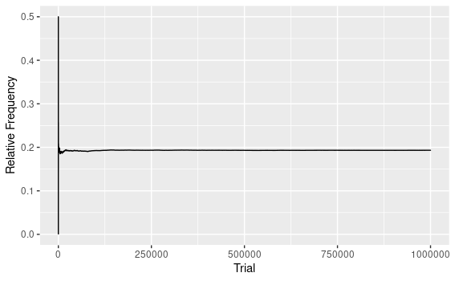

```r
set.seed(23)
num_reps <- 1000000
X_7 <- rep(NA, num_reps)

for(i in 1:num_reps) {
  coin_flips <- rbinom(12, 1, 0.5)
  X_7[i] <- sum(coin_flips == 1)
}

rel_freqs <- cumsum(X_7 == 7) / seq_along(X_7)

ggplot(data = data.frame(trial = 1:num_reps, relative_frequency = rel_freqs), aes(x = trial, y = relative_frequency)) +
  geom_line() +
  labs(x = "Trial", y = "Relative Frequency")
```

3. Explain how your observations match up with the frequentist interpretation of probability.

The frequentist interpretation of probability states that the probability of an event is the limit of the relative frequency of that event as the number of repetitions of the experiment approaches infinity. In our case, as we increase the number of repetitions of the experiment (i.e., the number of times we toss the coin 12 times), we observe that the relative frequency of obtaining 7 heads approaches the theoretical probability of P(X = 7). This is consistent with the frequentist interpretation of probability.

4. Compute E(X) and the observed average of the repetitions

The expected value of X is given by E(X) = np = 12 * 0.5 = 6

```r
mean(X_7)
```

```
[1] 6.000366
```

5. Do your observations match up with the law of large numbers?

The law of large numbers states that as the number of repetitions of an experiment increases, the sample mean approaches the true mean of the population. In our case, as we increase the number of repetitions of the experiment, we observe that the observed average of the repetitions approaches the expected value of X, which is consistent with the law of large numbers.

2. Experimentally verify the law of large numbers for the standard normal distribution and an exponential distribution with λ = 4

For the standard normal distribution, the law of large numbers states that the sample mean of a large number of independent and identically distributed normal random variables will converge to the population mean. Similarly, for an exponential distribution with parameter λ, the sample mean will converge to the population mean 1/λ

For the standard distribution

```r
set.seed(1)
n <- c(10, 100, 1000, 10000, 100000)

for (i in n) {
  x <- rnorm(i)
  print(mean(x))
}
```

```
[1] 0.1322028
[1] 0.1304151
[1] -0.02765614
[1] -0.006409792
[1] -0.001154808
```

For the Exponential Distribution

```r
set.seed(1)
n <- c(10, 100, 1000, 10000, 100000)

for (i in n) {
  x <- rexp(i, rate = 4)
  print(mean(x))
}
```

```
[1] 0.2106556
[1] 0.2641332
[1] 0.2532055
[1] 0.2479815
[1] 0.2504801
```

3. (Simulating the lottery) Modify the above code to display the frequencies (or the relative frequencies) of the sums. Summarize your observations.

| ticket | counts |
| --- | --- |
| 111 | 539 |
| 112 | 612 |
| 113 | 566 |
| 121 | 546 |
| 122 | 557 |
| 123 | 601 |
| 131 | 508 |
| 132 | 519 |
| 133 | 554 |
| 211 | 549 |

[output cut: 17 more lines]

| sum | counts |
| --- | --- |
| 3 | 539 |
| 4 | 1707 |
| 5 | 3251 |
| 6 | 3940 |
| 7 | 3346 |
| 8 | 1662 |
| 9 | 555 |

```
NA
```

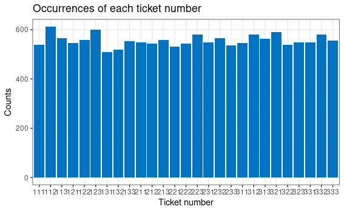

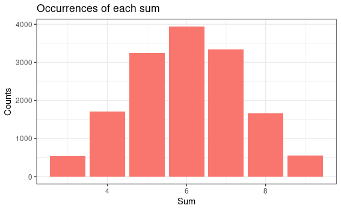

```r
library('tidyverse')

# Function that mimics the lottery and graphs
lottery <- function(seed = 1, iterations = 15000) {
  # Set seed for reproducibility
  set.seed(seed)

  # Generate n sets of ticket numbers where a ticket number is a set of three
  # integers between 1 and 4 inclusive
  num1 <- floor(runif(n = iterations, min = 1, max = 4))
  num2 <- floor(runif(n = iterations, min = 1, max = 4))
  num3 <- floor(runif(n = iterations, min = 1, max = 4))

  # Calculate sum of each ticket
  sum <- num1 + num2 + num3

  # Create dataframe with ticket numbers in order to make easier to graph
  ticket <- 100*num1 + 10*num2 + num3
  ticket <- as.data.frame(ticket)

  # Count occurrences of each ticket number
  df_ticket <- ticket %>%
    group_by(ticket) %>%
    summarise(counts = n())

  # Count occurrences of each sum
  df_sum <- data.frame(sum)
  df_sum$counts <- 1
  df_sum <- df_sum %>%
    group_by(sum) %>%
    summarise(counts = n())

  # Graphs occurrences of each ticket number
  df_ticket$ticket <- as.factor(df_ticket$ticket)
  p1 <- ggplot(df_ticket, aes(x = ticket, y = counts)) +
    geom_bar(fill = "#0073C2FF", stat='identity') +
    theme_bw() +
    labs(title = "Occurrences of each ticket number",
         x = "Ticket number",
         y = "Counts")

  # Graphs occurrences of each sum
  p2 <- ggplot(df_sum, aes(x = sum, y = counts)) +
    geom_bar(fill = "#F8766D", stat='identity') +
    theme_bw() +
    labs(title = "Occurrences of each sum",
         x = "Sum",
         y = "Counts")

  print(p1)
  print(p2)

  return(list(df_ticket, df_sum))
}

lottery()
```